# One Chart, Two Realities: Simpson’s Paradox at Work

- Show All Code
- Hide All Code
- View Source

A People Analytics Guide to Spotting Trend Reversals in Workforce Data

People Analytics

Simpon’s Paradox

R Programming

Data Visualization

Confounding Factors

Two case studies illustrating how apparent trends in workforce data can reverse dramatically across or within subgroups.

Author

Gordon Goodwin

Published

April 6, 2025

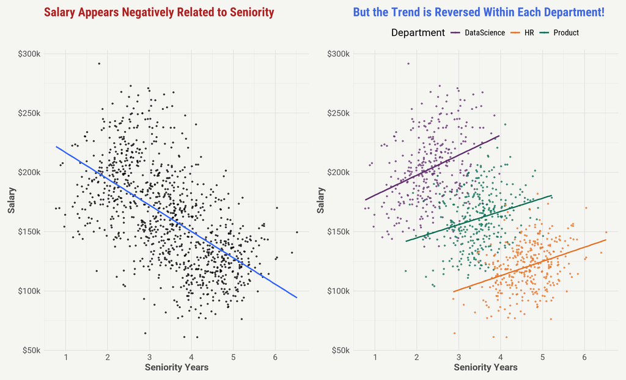

Figure 1: Illustration of Simpson’s Paradox at work. Compensation within the general employee population is negatively related to seniority, but the trend reverses when the data are sliced by org. Within each department, employees with higher seniority levels tend to command higher salaries.

# Overview

**Simpson’s Paradox** is a phenomenon where an observed statistical relationship or trend reverses when the data are collapsed across or stratified by subgroups.

In workforce data, Simpson’s Paradox typically manifests in one of 2 main ways:

- **Top-Down**: an association observed within an employee population reverses when data are sliced by smaller employee subgroups.
- **Bottom’s Up**: an association first observed within employee subgroups reverses when data from the groups are combined.

In this guide we’ll use 2 people analytics case studies to illustrate how to identify and control for the paradox using `R`.

# Case Study #1

The Chief People Officer (CPO) of a small but growing tech company has asked us to examine the relationship between **employee compensation** and **seniority**

- The CPO is a staunch advocate of rewarding seniority with increased compensation.
- The company’s compensation strategy has been specifically designed to reflect this.

**The CPO has asked us to review whether salary and seniority are in fact positively related.**

## Packages & Set-Up

```r
knitr::opts_chunk$set(dev = "ragg_png")
# No Scientific Notation
options(scipen = 999)

# Packages
library(tidyverse)
library(tidymodels)
library(censored)
library(janitor)
library(ggfun)
library(survminer)
library(ggsurvfit)
library(patchwork)
library(ggfortify)
library(ggridges)
library(tidycmprsk)
library(skimr)
library(GGally)


# Source Helper/Utility Functions
## Fonts
source("font_setup.R")

## Theme
source("theme_setup.R")



# Visualization Parameters (Themes & Fonts)

# FONTS
## Adds Google Fonts & Sets Config
setup_fonts()

## Ties Font Family Names to List for Referencing
fonts <- get_font_families()



# COLORS
## Ties Default  Colors & Specified Palette to List References
colors <- get_theme_colors(
  palette = c(
    "#663171",
    "#ea7428",
    "#0c7156",
    "black",
    "firebrick",
    "#f9d14a",
    "#ff6153",
    "#1a318b",
    "#ce9462",
    "#3b3a3e",
    "#6d2f20",
    "skyblue1",
    "white",
    "wheat"
  )
)




# THEMES

## CREATE BASE THEME - uses font and color list refs internally
base_theme <- create_base_theme(colors = colors)


## Specify more theme elements to add to base theme (optional)
theme1 <- extend_base_theme(

  base_theme = base_theme,
  extended_elements =
    theme(
      plot.title = element_text(color = "grey20")
    )
)


# Set Theme
theme_set(theme1)
```

## Load & Preview Data

```r
# READ DATA
read_csv("Simpson_Paradox_Data_CS1.csv") -> dat1main


## Preview
dat1main |> head()
```

```
# A tibble: 6 × 6
  emp_ID department  seniority_weeks seniority_years  salary salary_k
  <chr>  <chr>                 <dbl>           <dbl>   <dbl>    <dbl>
1 x1     DataScience           119.             2.29 229428.     229.
2 x2     DataScience           130.             2.5  224341.     224.
3 x3     DataScience           111.             2.13 203871.     204.
4 x4     DataScience           136.             2.62 162068.     162.
5 x5     DataScience           107.             2.06 242161.     242.
6 x6     DataScience            67.2            1.29 164902.     165.
```

## Analysis

### Initial Trend

When we first plot salary against seniority for the general employee population, **it appears that compensation is negatively associated with years of seniority!**

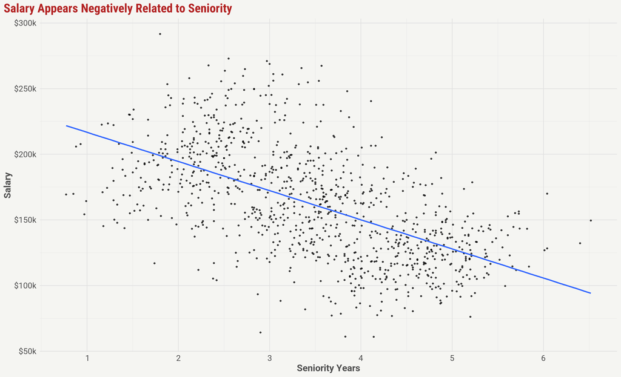

Figure 2: Illustration of the initial trend: When salary is plotted against seniority years for the general employee population, compensation appears to have a negative relationship with seniority.

```r
# Plot
dat1main |>
  ggplot(aes(x = seniority_years,
             y = salary_k)) +
  geom_point(size = 1, alpha = 0.7) +
  geom_smooth(method = "lm", se = F) +
  scale_x_continuous(breaks = seq(0, 10, 1)) +
  scale_y_continuous(labels = scales::label_dollar(suffix = "k")) +
  labs(x = "Seniority Years", y = "Salary",
       title = "Salary Appears Negatively Related to Seniority") +
  theme(plot.title = element_text(color = "firebrick")) -> p1main


p1main
```

A linear regression model confirms that after holding all other factors constant:

- **Each additional year of seniority is associated with a $22,000 *decrease* in average salary.**

```r
# Regression Model: Salary ~ Seniority
# Linear Regression Model
m1 <- lm(salary ~ seniority_years, data = dat1main)

# Tidy Model Output instead of ugly base R summary
tidy(m1)
```

```
# A tibble: 2 × 5
  term            estimate std.error statistic  p.value
  <chr>              <dbl>     <dbl>     <dbl>    <dbl>
1 (Intercept)      238930.     3587.      66.6 0
2 seniority_years  -22204.      982.     -22.6 1.09e-91
```

### Trend Reversal

When we slice our data by department, however, there is a definite trend reversal!

**For employees in the same department, compensation is *positively* related to seniority**

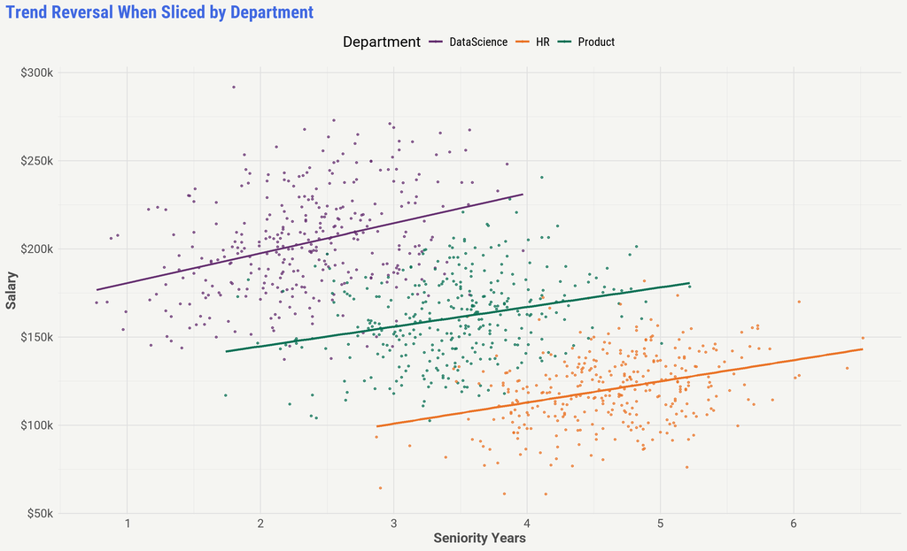

Figure 3: Illustration of the trend reversal: Within each departmental subgroup, employees with higher seniority levels tend to also have higher salaries.

```r
# Plot - WITHIN GROUPS
dat1main |>
  ggplot(aes(x = seniority_years,
             y = salary_k,
             color = department)) +
  geom_point(size = 1, alpha = 0.7) +
  geom_smooth(method = "lm", se = F) +
  scale_x_continuous(breaks = seq(0, 10, 1)) +
  scale_y_continuous(labels = label_dollar(suffix = "k")) +
  scale_color_manual(values = c(colors$palette[1], colors$palette[2], colors$palette[3])) +
  labs(x = "Seniority Years", y = "Salary", color = "Department",
       title = "Trend Reversal When Sliced by Department") +
  theme(plot.title = element_text(color = "royalblue"),
        legend.text = element_text(family = fonts$title)) -> p1reverse


p1reverse
```

A **multivariate regression model** confirms this, showing that when holding all else constant:

- **After controlling for departmental differences, each additional year of seniority is now associated with a $13,500 increase in average salary!**
- Compared to the Data Science employees (our model reference group), Product team members earn $57K less on average, and HR employees earn $113.6K less!

```r
# Regression Model: Salary ~ Seniority
# Linear Regression Model
m1b_reversal <- lm(salary ~ seniority_years + department, data = dat1main)

# Tidy Model Output
tidy(m1b_reversal)
```

```
# A tibble: 4 × 5
  term              estimate std.error statistic   p.value
  <chr>                <dbl>     <dbl>     <dbl>     <dbl>
1 (Intercept)        171920.     3296.      52.2 6.10e-287
2 seniority_years     13425.     1290.      10.4 3.89e- 24
3 departmentHR      -113656.     3490.     -32.6 5.79e-159
4 departmentProduct  -57394.     2344.     -24.5 5.13e-104
```

### Explaining the Reversal

*So how is it that the initial trend completely reversed when we sliced by department?*

When we visualize all of our variables simultaneously, we can see that:

- **Salary & Seniority both vary by department, but in opposite directions**
- **Salary** (top right & bottom right boxes):Data Science employees tend to be the highest paid, HR employees tend to be the lowest paid, and Product employees fall in the middle.
- **Seniority** (middle col/top and middle rows): On average, HR employees are the longest-tenured, Data Science employees are the newest, and Product employees are again somewhere in the middle.
- **Salary and seniority are negatively correlated overall, but positively correlated within departments** (far right col/middle row). This is the Paradox in a nutshell.

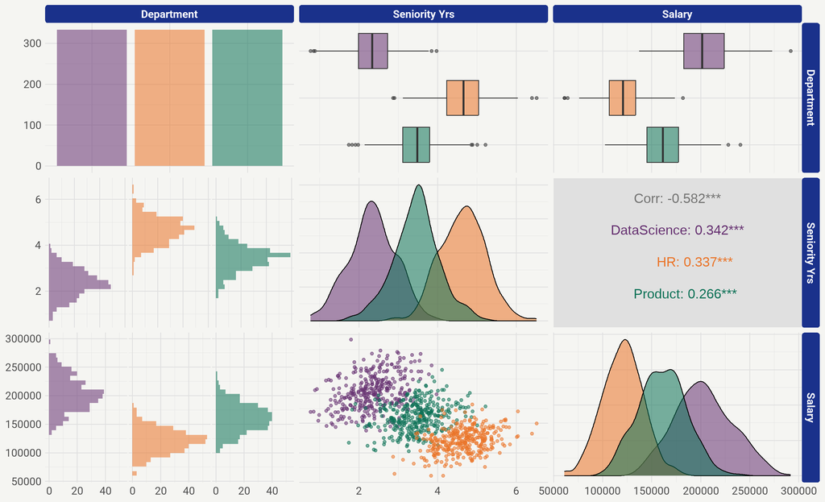

Figure 4: Pairs Matrix showing the univariate and bivariate distributions of department, salary, and seniority.

```r
# Plot
dat1main |>
  select(c(Department = department,
           `Seniority Yrs` = seniority_years,
           Salary = salary)) |>
  ggpairs(aes(color = Department, alpha = 0.4)) +
  scale_color_manual(values = c(colors$palette[1],
                                colors$palette[2],
                                colors$palette[3])) +
  scale_fill_manual(values = c(colors$palette[1],
                                colors$palette[2],
                                colors$palette[3]))
```

### Recap

**Salary appears to vary negatively with seniority at the company-wide level because the higher-seniority employees are concentrated in the lower-paying departments.**

In other words, **department acts as a confounding factor for the association between salary and seniority**. *Within each department*, the association is positive.

# Case Study #2

The CPO was so impressed by our insights that he has a new project for us! Now he wants us to analyze the relationship between employee **pre-hire sourcing** and **job satisfaction**.

- Prior analyses found that referrals tend to perform better than those who applied traditionally.
- Job Satisfaction is a critical KPI, and the company routinely administers surveys to monitor it.

**The CPO wants us to use survey and pre-hire sourcing data to determine whether referred employees are more likely to rate their job satisfaction favorably than traditional applicants.**

## Load and Preview Data

- Pre-Hire Source (Referred vs Applied)
- Job Satisfaction (Favorable vs Unfavorable)
- Location (Remote vs Office)

```r
# READ DATA
read_csv("Simpson_Paradox_Data_CS2.csv") -> dat2main


## Preview
dat2main |> head(n = 5)
```

```
# A tibble: 5 × 4
  emp_ID referral location satisfied
  <chr>  <chr>    <chr>    <chr>
1 x1     Referred Remote   Favorable
2 x2     Referred Remote   Unfavorable
3 x3     Referred Remote   Unfavorable
4 x4     Referred Remote   Favorable
5 x5     Referred Remote   Unfavorable
```

## Analysis

### Initial Trend

When we plot the initial relationship between job satisfaction and pre-hire source, **it appears that referred employees are *less likely* to rate their job satisfaction favorably!**

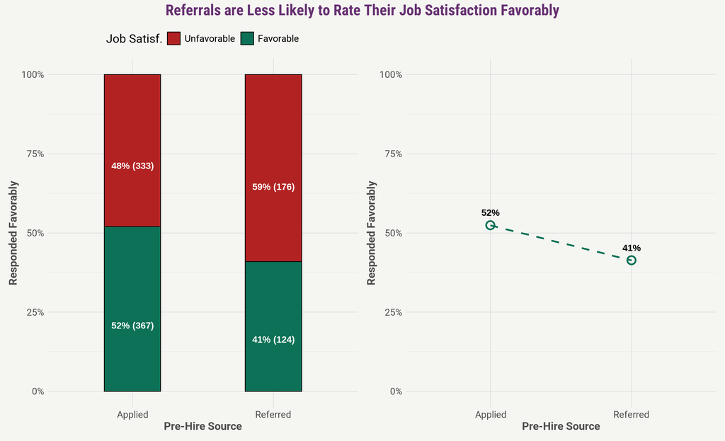

Figure 5: Stacked-Bar (left) and Trend Line (right) plots visualizing job satisfaction favorability for referrals and traditional applicants. Both plots show that referred employees tend to have lower job satisfaction levels.

```r
# Plot A) Stacked Bar
dat2main |>
  count(referral, satisfied) |>
  mutate(prop = round(n/sum(n),2),
         prop_label = glue::glue("{scales::percent(prop)} ({n})"),
         .by = referral) |>
  mutate(satisfied = fct_relevel(satisfied, c("Unfavorable","Favorable"))) |>
  # filter(satisfied == "Favorable") |>
  ggplot(aes(x = referral,
             y = prop,
             fill = satisfied)) +
  geom_col(width = 0.4, color = "black") +
  scale_y_continuous(labels = scales::label_percent()) +
  coord_cartesian(ylim = c(0, 1)) +
  geom_text(aes(label = prop_label),
            position = position_stack(vjust = .4),
            colour = colors$palette[13], size = 3,
            fontface = "bold") +
  scale_fill_manual(values = c(colors$palette[5], colors$palette[3])) +
  labs(x = "Pre-Hire Source",
       y = "Responded Favorably",
       fill = "Job Satisf.") +
  theme(plot.title = element_text(color = colors$palette[1])) -> p2a


# Plot B) Trend Line
dat2main |>
  count(referral, satisfied) |>
  mutate(prop = n / sum(n), .by = referral) |>
  filter(satisfied == "Favorable") |>  # Keep only favorability data
  ggplot(aes(x = referral, y = prop, group = 1)) +
  geom_line(color = colors$palette[3], linewidth = 1.2, lty = 2) +
  geom_point(size = 4, color = colors$palette[3],
             shape = 1, stroke = 1.5) +
  scale_y_continuous(labels = scales::label_percent(), limits = c(0, 1)) +
  labs(
    x = "Pre-Hire Source",
    y = "Responded Favorably"
  ) +
  geom_text(aes(label = scales::percent(prop, accuracy = 1)),
            vjust = -1.5,
            color = colors$palette[4],
            fontface = "bold", size = 3) -> p2b


# Side-by-Side
p2a + p2b +
  plot_annotation(title = "Referrals are Less Likely to Rate Their Job Satisfaction Favorably",
                  theme = theme(
                    plot.title = element_text(color = colors$palette[1],size = 14,hjust = 0.5)
                  ))
```

A **logistic regression model** confirms that, holding all else constant,:

- **Referred employees are 64% as likely (36% less likely) to rate their jobs favorably in comparison to traditional applicants.**

```r
# Logistic Regression Model
## -> Favorable Y/N ~ Referral Status

# Convert Satisfaction (Favorable/Unfavorable) to 1/0 for model
dat2main$satisfied_recoded <- ifelse(dat2main$satisfied == "Favorable",1,0)

# Relabel referral and location for legibility
dat2main$referral <- factor(dat2main$referral, labels = c("No","Yes"))

# Logistic regression model
m3a <- glm(satisfied_recoded ~ referral, data = dat2main, family = "binomial")

# Tidy Model Output rounded to 3 digits (Exponentiated Coefficients to get Odds Ratios)
tidy(m3a) |>
  mutate(across(where(is.numeric),
                ~round(.x, 3))) |>
  # Exponentiate to get odds ratio
  mutate(`exp(estimate)` = exp(estimate), .before = estimate)
```

```
# A tibble: 2 × 6
  term        `exp(estimate)` estimate std.error statistic p.value
  <chr>                 <dbl>    <dbl>     <dbl>     <dbl>   <dbl>
1 (Intercept)           1.10     0.097     0.076      1.28   0.199
2 referralYes           0.640   -0.447     0.14      -3.21   0.001
```

### Trend Reversal

When we slice our data by work location (Office vs Remote), however, we see another trend reversal!

**Within each work modality, referred employees are more likely to be satisfed than those who applied traditionally.**

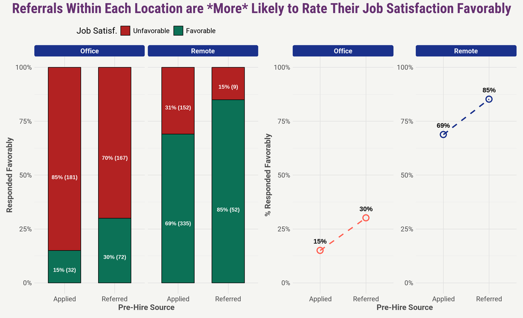

Figure 6: Stacked-Bar (left) and Trend Line (right) plots that facet by work location type before visualizing job satisfaction favorability by pre-hire source. Both plots show that after accounting for work modality, referred employees tend to rate their job satisfaction more favorably than traditional applicants.

```r
# Plot A) Stacked Bar ~ Location
dat2main |>
  count(referral, satisfied, location) |>
  mutate(prop = round(n/sum(n),2),
         prop_label = glue::glue("{scales::percent(prop)} ({n})"),
         .by = c(referral, location)) |>
  mutate(satisfied = fct_relevel(satisfied, c("Unfavorable","Favorable"))) |>
  # filter(satisfied == "Favorable") |>
  ggplot(aes(x = referral,
             y = prop,
             fill = satisfied)) +
  geom_col(width = 0.65, color = "black") +
  scale_y_continuous(labels = scales::label_percent()) +
  coord_cartesian(ylim = c(0, 1)) +
  geom_text(aes(label = prop_label),
            position = position_stack(vjust = .4),
            colour = colors$palette[13], size = 2.5,
            fontface = "bold") +
  facet_wrap(~location) +
  labs(x = "Pre-Hire Source",
       y = "Responded Favorably",
       fill = "Job Satisf.") +
 # theme(legend.position = "right") +
  scale_fill_manual(values = c(colors$palette[5],colors$palette[3])) -> p3a


p3a +
  ggtitle("Referrals Within Each Location are *More* Likely to Rate Their Job Satisfaction Favorably") +
  theme(
    plot.title = element_text(color = colors$palette[1]),
  )




# Plot B) Trend Line ~ Location
dat2main |>
  count(referral, satisfied, location) |>
  mutate(prop = n / sum(n), .by = c(referral, location)) |>
  filter(satisfied == "Favorable") |>  # Keep only favorability data
  ggplot(aes(x = referral, y = prop, color = location, group = location)) +
  geom_line(size = 1.2, lty = 2) +
  geom_point(size = 4,
             shape = 1, stroke = 1.5) +
  geom_text(aes(label = scales::percent(prop, accuracy = 1)),
            vjust = -1.5,
            color = colors$palette[4],
            fontface = "bold", size = 3) +
  scale_y_continuous(labels = scales::label_percent(), limits = c(0, 1)) +
  scale_color_manual(values = c(colors$palette[7],colors$palette[8])) +
  facet_wrap(~location, scales = "free_y") +
  labs(
    x = "Pre-Hire Source",
    y = "% Responded Favorably",
  ) +
  theme(legend.position = "none") -> p3b


p3b +
  ggtitle("Referrals Within Each Location are *More* Likely to Rate Their Job Satisfaction Favorably") +
  theme(
    plot.title = element_text(color = colors$palette[1]),
  )



# SIDE BY SIDE
p3a + p3b +
  plot_annotation(title = "Referrals Within Each Location are *More* Likely to Rate Their Job Satisfaction Favorably",
                  theme = theme(
                    plot.title = element_text(color = colors$palette[1],size = 18,hjust = 0.5)
                  ))
```

A **multivariate logistic regression model** confirms the reversal:

- **After controlling for work environment, referred employees are ~2.5x more likely to rate their satisfaction favorably!**
- **Remote team members are over 12.5x more likely to rate their jobs favorably** in comparison to In-Office employees (our model reference group).

```r
# Logistic Regression Model
## -> Favorable Y/N ~ Referral Status + Location

# Logistic regression model
m3 <- glm(satisfied_recoded ~ referral + location, data = dat2main, family = "binomial")

# Tidy Model Output rounded to 3 digits (Exponentiated Coefficients to get Odds Ratios)
tidy(m3) |>
  mutate(across(where(is.numeric),
                ~round(.x, 3))) |>
  # Exponentiate to get odds ratio
  mutate(`exp(estimate)` = exp(estimate), .before = estimate)
```

```
# A tibble: 3 × 6
  term           `exp(estimate)` estimate std.error statistic p.value
  <chr>                    <dbl>    <dbl>     <dbl>     <dbl>   <dbl>
1 (Intercept)              0.174   -1.75      0.173    -10.1        0
2 referralYes              2.49     0.913     0.2        4.56       0
3 locationRemote          12.7      2.54      0.188     13.5        0
```

### Explaining the Reversal

*So how is it that the initial trend completely reversed when we sliced by Office/Remote status?*

When we visualize sourcing, satisfaction, and location simultaneously, we can see that:

- *Referred employees are more likely to be office-based, and office-based employees are less likely to be satisfied.*
- *Traditional applicants are more likely to work remotely, and remote employees are more likely to be satisfied.*
- **Within each location type, referrals are more likely to be satisfied than traditional applicants.**

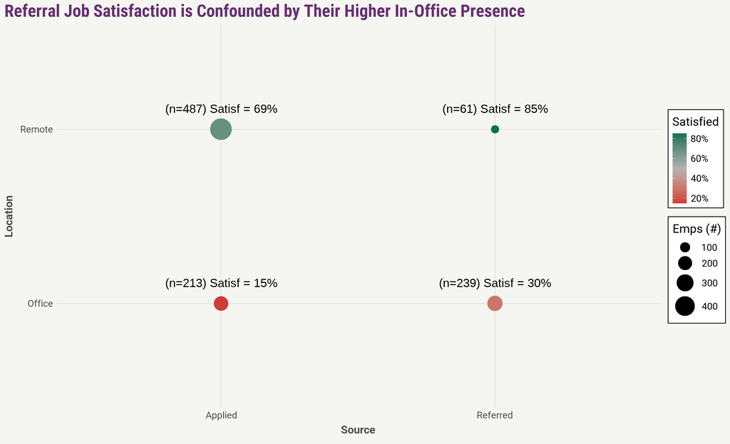

Figure 7: Illustration of how sample size imbalances lead to a trend reversal after controlling for location type. Bubble sizing corresponds to sample size, and shows us that referred employees are heavily Office-based, while traditional applicants are predominantly Remote. Color gradient maps to the proportion who rated their jobs favorably, which shows us that Office-based employees are significantly less-satisfied than Remote workers. Finally, within each work modality, referrals are much more likely to respond favorably.

```r
# Crosstab (used by plots): Prop & Counts Satisfied by Referral/Applied & Office/Remote cuts
dat2main |>
  summarize(prop_satisfied = mean(satisfied == "Favorable"),
            count_satisfied = sum(satisfied == "Favorable"),
            count_NOTsatisfied = sum(satisfied != "Favorable"),
            n = n(),
            .by = c(referral, location)) |>
  mutate(prop_label = glue::glue("(n={n}) Satisf = {scales::percent(prop_satisfied)}")) |>
  arrange(referral, location) -> tab1


tab1

# Plot A) Bubble Viz
tab1 |>
  mutate(referral = if_else(referral=="Yes","Referred","Applied")) |>
  ggplot(aes(x = referral, y = location)) +
  geom_point(aes(size = n, color = prop_satisfied)) +
  scale_color_gradient2(low = "#cf3a36",
                        mid = "grey70",
                        high = "#0c7156",
                        midpoint = .5,
                        labels = scales::label_percent()) +
  # scale_color_viridis_c(option = "H", direction = 1) +
  scale_size_area(max_size = 12) +
  theme(legend.position = "right",
        plot.title = element_text(color = colors$palette[1], size = 16),
        legend.background = element_rect(color = colors$palette[4])) +
  labs(x = "Source", y = "Location",
       size = "Emps (#)", color = "Satisfied",
       title = "Referral Job Satisfaction is Confounded by Their Higher In-Office Presence") +
  geom_text(aes(x = referral,
                y = location,
                label = prop_label),
            color = colors$palette[4],
            vjust = -2)
```

We can see the same **sample size imbalances** in a **mosaic plot:**

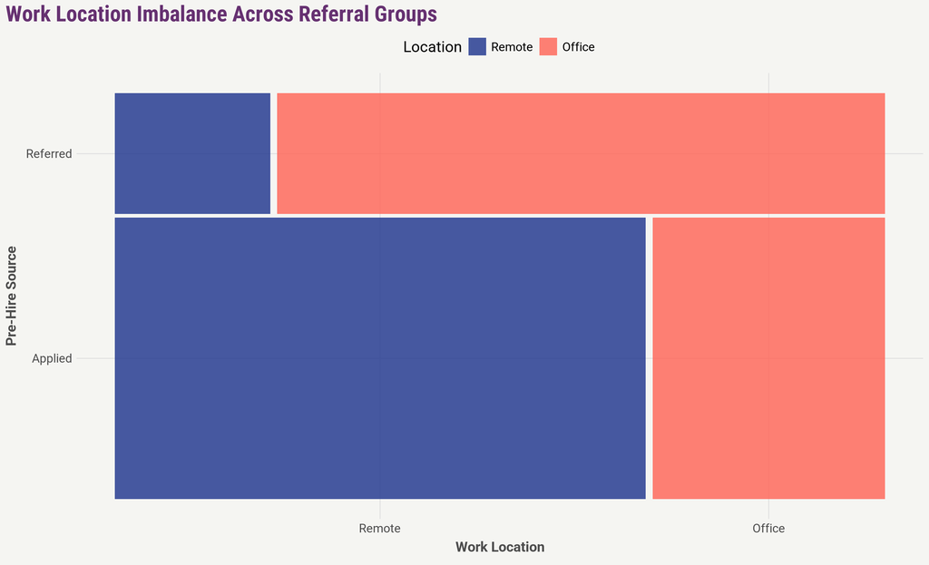

Figure 8: Mosaic plot visualization of the underlying sample size imbalances across (Office vs Remote) and (Referred vs Applied) subgroups. As in the bubble plot, the mosaic plot highlights the fact that traditional applicants are skewed heavily towards Remote work environments, while referred employees are much more likely to be Office-based.

```r
# Plot B) Mosaic Plot

# Mosaic Plot of Sample Size Imbalance Across Locations
dat2main |>
  mutate(referral = factor(referral, labels = c("Applied","Referred")),
         location = fct(location),
         satisfied = fct(satisfied)) |>
  ggplot() +
  geom_mosaic(aes(x = product(location, referral), fill = location), show.legend = T) +
 # theme_mosaic() +
  scale_fill_manual(values = c(colors$palette[8],colors$palette[7])) +
  coord_flip() +
  theme(plot.title = element_text(color = colors$palette[1], size = 16),
        legend.position = "top") +
  labs(y = "Work Location",
       x = "Pre-Hire Source",
       fill = "Location",
       title = "Work Location Imbalance Across Referral Groups")
```

### Recap

*Referred employees appear to be less satisfied overall because they are predominantly office-based, and office teams tend to be less satisfied than remote teams regardless of pre-hire source.*

In other words, **location type acts as a confounding factor for the association between referral status and job favorability.** Location masks the fact that within each work modality, referred employees tend to view their jobs more favorably than traditional applicants.